# PPOL 567 Massive Data Fundamentals

## Final Project : Team 6

## Exploratory Data Analysis

## Executive Summary

Given below are our 10 business goals and corresponding technical proposals for this project.

## Exploratory Data Analysis Goals

### Business Goal - 1

**Analyze the user activity in the r/worldnews subreddit. What proportion of users participate in posting submissions and comments? Who are the users with the most controversial comments? Does controversiality also inform whether a user is likely to have gilded/distinguished comments?**  
**Technical proposal** : Different aggregate tables will be created to answer the questions above. The number of distinct users posting or commenting would be compared against the total number of subscribers in the subreddit(obtained from an external source). Users with highest number of controversial comments will be listed and their total gilded and distinguished comments will be assessed.

### Business Goal - 2

**What are the general trends in submissions and comments in the world news subreddit ? How do characteristic features of the subreddit vary across time and compare with the general trend ?**  
**Technical Proposal** : In order to perform time series analysis, the timestamp of the submission’s creation will be used. Data manipulations to find counts, averages, medians and other such arithmetic measures of different variables in the dataset will be performed. These calculations will then be visualized over time to identify different trends in the data, check if they are consistent or not, and if possible, identify seasonality in the time series visualizations.

### Business Goal -3

**What are the most popular new stories in the subreddit? What are the most shared news sites? Are there any live threads? If so, what are they pertaining to?**  
**Technical proposal** : The most popular news stories can be derived from the score variable. The most shared news sites can be captured by aggregating on the domain column and assessing for the number of posts, comments, the average scores to name a few. It can also be determined if the news sites have any articles that are among the top popular ones. Live threads can be obtained using regex on the title column by applying an appropriate search term.

### Business Goal - 4

**What are the most repetitive words in the comments under the top 5 news stories in the subreddit?**  
**Technical Proposal** : By filtering the “score” column from the dataset, the most popular subreddits can be found. Then word clouds can be created to explore the most frequent words in each of the top five subreddits. These visualizations give a take-away of the popular topics in the subreddit.

### Business Goal - 5

**Does world news subreddit capture all events in the Russia-Ukraine conflict?**  
**Technical Proposal** : In order to compare posts regarding the Russia-Ukraine conflict, the ACLED (Armed Conflict Location & Event Data Project) data was used. The ACLED data for Ukraine and Russia were aggregated to obtain daily counts of sub-event types in the following categories: Armed Clashes Shelling/Artillery/Missile Attacks Remote Explosives/Landmines/IED Disrupted Weapons Use Based on the definitions of the aforementioned sub-events from the ACLED codebook, appropriate words were used to find daily counts of event type from posts’s title using regex. Then, both the datasets are merged on the event date, and their counts are compared using a heatmap.

## Natural Language Processing Goals

### Business Goal - 6:

**What are the main topics in the submissions of the sub-reddit ?**  
**Technical Proposal** : In order to identify the major topics under submissions related to the Russia - Ukraine crisis, topic modeling with LDA will be performed. Particularly, the LDA method for topic modeling will be used as its results are based on conditional probability estimates. Titles will be pre-processed to remove stop-words, punctuations, and non-alpha characters (this ensures that titles in languages other than English are removed from analysis). The ideal minimum document frequency for LDA will be found with TF-IDF( Term Frequency - Inverse Document Frequency).

### Business Goal - 7:

**What are the key elements in the submissions and what categories can be they classified to?**  
**Technical Proposal** : Named Entity recognition will be performed using the spacy package in Python. Apart from the predetermined ‘ents’ properties in the package, additional relevant labels will be created based on results from word clouds.The possibility of creating relevant labels for high frequency words in languages other than English in the dataset will be explored too. Together, they shall be used to identify standard categories in the text data such as person’s name, geographic locations, organizations, monetary values etc.

### Business Goal - 8

**What is the sentiment of comments under live thread posts? From previous analysis it was determined that the live threads were pertaining to Russia’s war against Ukraine. Given such a high stakes topic, do we expect the sentiment to be heavily one-sided or it is possible that there might be highly mixed views?**  
**Technical Proposal** : For conducting sentiment analysis, we propose to use a lexicon based approach using easily available lexicons like VaderSentiment and TextBlob. After preprocessing our texts and generating the labels using lexicons, we plan to either compare it against pre-trained models available through huggingface and also against a small subset of hand labeled sentiments.

## Machine Learning Goals

### Business Goal - 9

**Is it possible to scale our NLP models using supervised learning? How well would they perform and would the traditional evaluation metrics in supervised learning be useful in designing high performing models?**

**Technical Proposal** : After creating the sentiment analysis and topic models above, it is possible to train supervised models such as support vector machines, logistic regression etc. using the sentiment or topic labels as the target variable. A portion of the data can be used in topic modeling and sentiment analysis to obtain the required labels and the remaining data can be labeled by training supervised learning models.

### Business Goal - 10

**Could individual user Karma scores be predicted by the variables in our dataset?**

**Technical Proposal** : Karma scores can often influence any user’s actions on a particular subreddit. After obtaining the set of users who post and comment, their Karma scores can be procured using the Reddit API. The Karma scores would then become our target variable and we can construct a number of predictors from the dataset such as number of submissions or comments posted, number of gilded comments etc.

### Exploratory Data Analysis

We assessed the basic specifications of the dataset, removed duplicates and anomalies and conducted the following analyses.

### User Behaviour

|  | User | Controversial Comments | Gilded Comments | Distinguished Comments |
| --- | --- | --- | --- | --- |
| 0 | catsinbananahats | 382 | 2 | 0 |
| 1 | Torifyme12 | 355 | 3 | 0 |
| 2 | green_flash | 335 | 7 | 13 |
| 3 | ylteicz123 | 317 | 2 | 0 |
| 4 | Test19s | 307 | 5 | 0 |
| 5 | IsraeliDonut | 306 | 4 | 0 |
| 6 | KeyWestTime | 299 | 4 | 0 |
| 7 | Freschledditor | 290 | 1 | 0 |
| 8 | HamburgerEarmuff | 281 | 1 | 0 |
| 9 | Goshdang56 | 275 | 0 | 0 |
| 10 | _Plork_ | 271 | 1 | 0 |
| 11 | stretching_holes | 270 | 3 | 0 |
| 12 | feeltheslipstream | 267 | 2 | 0 |
| 13 | timelyparadox | 260 | 3 | 0 |
| 14 | Silurio1 | 252 | 0 | 0 |
| 15 | InnocentTailor | 245 | 0 | 0 |
| 16 | JPR_FI | 245 | 0 | 0 |
| 17 | albertnormandy | 241 | 0 | 0 |
| 18 | Foreign-Engine8678 | 239 | 2 | 0 |
| 19 | pieter1234569 | 238 | 0 | 0 |

From the table above it is immediately apparent that controversial comments don't seem to have much impact on whether the user also has gilded and distinguished comments.

### Time Series Analysis

Time series analysis of big data helps in identifying underlying trends and how they change over time. For the world news subreddit used in this project, the data ranges from January 1, 2022 to January 31, 2023. Due to the presence of this date variable that informs us about the date on which a particular submission or post was made, we obtained the opportunity to generate several time series visualizations. They are presented below.

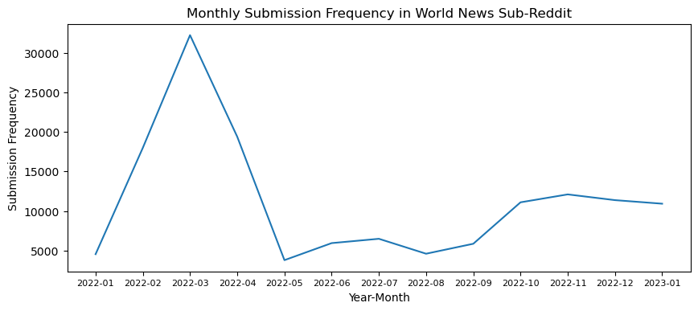

From the above visualization, it can be interpreted that there was a large spike in the number of submissions in March 2022. This can be attributed to the increased number of news articles on the advent of the Russia-Ukraine crisis. A smaller, but significant spike in October and November 2022 can be attributed to the conflict escalating to Phase-4, which marks massive strikes against Ukrainian infrastructure, Elon Musk buying Twitter, and the FIFA Football WorldCup 2022.

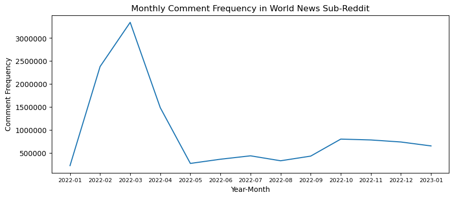

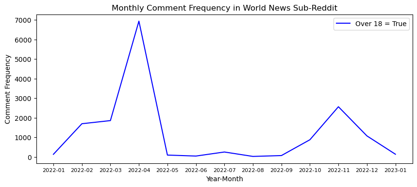

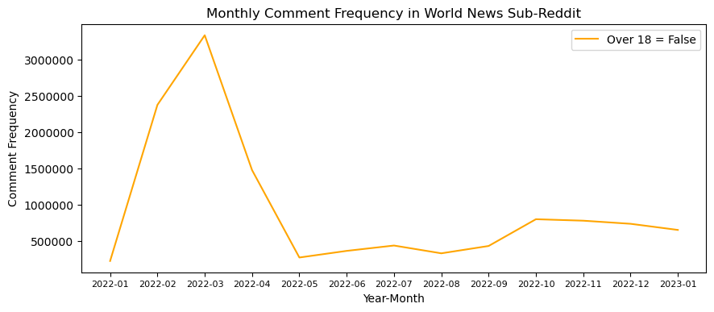

The time-series analysis for the comment frequencies of the subreddit posts follow the same pattern as the submission frequency. However, it is interesting to note that, albeit lesser in number to total comments, the count of NSFW comments is always higher a month after spikes in submission frequencies. This suggests that when there are more NSFW comments, after the subreddit has higher activity and engagement.

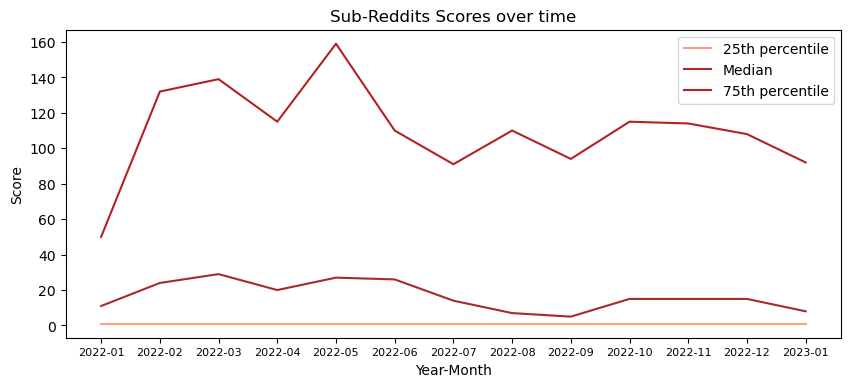

The above time series analysis revealed that median and 25th percentile scores don’t vary much over time. However, the 75th percentile (posts with higher upvotes) varies more over time. These spikes are not consistent with the submission and comment frequency spikes.

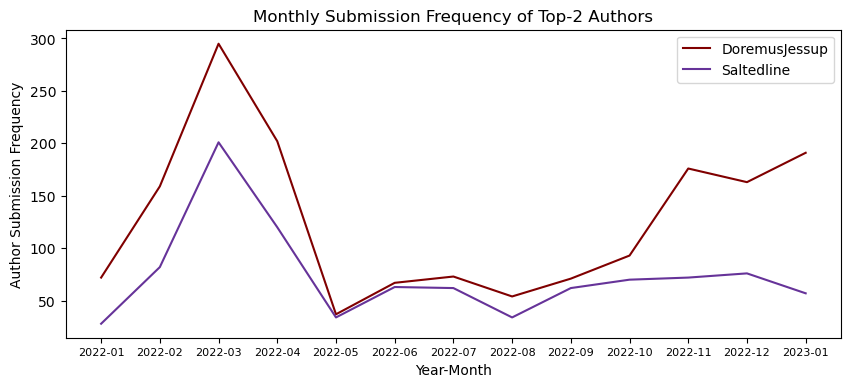

Finally, the submission frequency of the top two authors, Doremusjessup and Saltedline, were visualized. This time series analysis is similar to the overall submission and comment frequency over time for this subreddit. However, Doresmusjessup contributed more submissions in the second half of the year. This indicates that certain authors may have had increased activities over certain time-periods, and requires further exploration.

### Most Popular News

In the submissions and comments frequency graph above, a sharp peak was observed which could be associated to the ongoing war in Ukraine. The following analysis looks at the most highly scored news stories, the news sites that occur most in the submissions dataset, the presence of a live thread and how it compares with usual submissions.

|  | News Site | No of Posts | Average Score | Total Comments | No. of Posts in Top 100 |
| --- | --- | --- | --- | --- | --- |
| 0 | reuters.com | 10408 | 1016.02 | 950262 | 2 |
| 1 | theguardian.com | 5302 | 799.05 | 369019 | 3 |
| 2 | bbc.com | 3723 | 406.55 | 150287 | 0 |
| 3 | youtube.com | 3270 | 0.99 | 1395 | 0 |
| 4 | youtu.be | 3155 | 0.99 | 1478 | 0 |
| 5 | apnews.com | 2781 | 829.10 | 193889 | 2 |
| 6 | aljazeera.com | 2124 | 413.45 | 93387 | 0 |
| 7 | businessinsider.com | 2100 | 3835.48 | 561072 | 12 |
| 8 | cnn.com | 1931 | 833.87 | 157210 | 3 |
| 9 | pravda.com.ua | 1701 | 2859.35 | 317535 | 7 |
| 10 | newsweek.com | 1657 | 2492.05 | 365684 | 4 |
| 11 | bbc.co.uk | 1649 | 1027.57 | 157032 | 4 |
| 12 | timesofisrael.com | 1516 | 1060.57 | 143148 | 5 |
| 13 | twitter.com | 1426 | 1.06 | 394 | 0 |
| 14 | edition.cnn.com | 1424 | 925.04 | 117081 | 2 |
| 15 | france24.com | 1378 | 782.91 | 83893 | 0 |
| 16 | msn.com | 1354 | 1195.12 | 175598 | 2 |
| 17 | nytimes.com | 1226 | 702.73 | 72084 | 1 |
| 18 | dw.com | 1224 | 806.94 | 79069 | 0 |
| 19 | news.sky.com | 1176 | 1710.98 | 193797 | 3 |

As can be seen above, the most popular news sites on the subreddit over the past year is generally from western countries. This might affect the type of articles and news being spread in this particular subreddit. Further the average scores of most shared news sites are higher than for platforms like youtube and twitter. Even though reuters is the most commonly posted news site, its average scores are less than businessinsider and a few other news channels. This may have to do with the type of news being posted.

Live thread submissions were found and it was determined that all the live thread submissions were pertaining to the war. This provided an opportunity to evaluate the comments of the live thread against regular submissions dealing with the war as shown in the table below.

|  | Total Posts | Total Comments | Controversial Comments | Gilded Comments | Distinguished comments |
| --- | --- | --- | --- | --- | --- |
| 0 | 353 | 1824577 | 2.84 | 0.03 | 0.05 |
| 1 | 45863 | 6347014 | 4.48 | 0.05 | 0.10 |

The table above captures the percentage of comments that were controversial, gilded and distinguished for the live thread and for normal submissions dealing with the war. More controversiality is present in regular submissions as compared to live thread, possible due to larger number of normal posts.

### Searching for potential topics in comments

In this section we look at which are most commonly used words or phrases in the comments of the top 5 news stories. To evaluate this we generated word clouds.

The generated word clouds are displayed below :

For news story 1 :

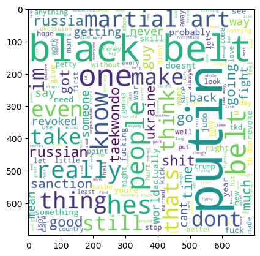

For news story 2 :

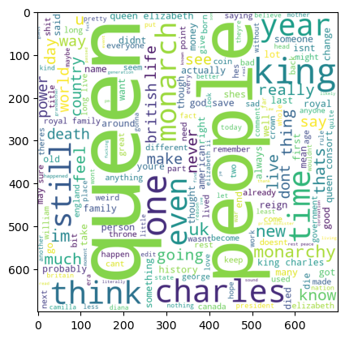

For news story 3 :

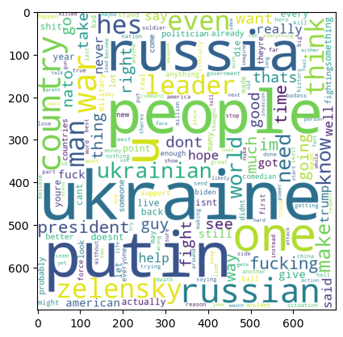

For news story 4 :

[figure not shown]

For news story 5 :

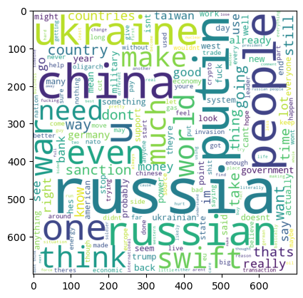

### Comparing with another data source

We have used the ACLED data to compare against our subreddit data. The Armed Conflict Location & Event Data Project (ACLED) collects real-time data on locations, dates, actors, fatalities and types of all reported political violence and protest events around the world, from various international and regional news sources. Since both the datasets are obtained from news sources, we performed an analysis to compare them.

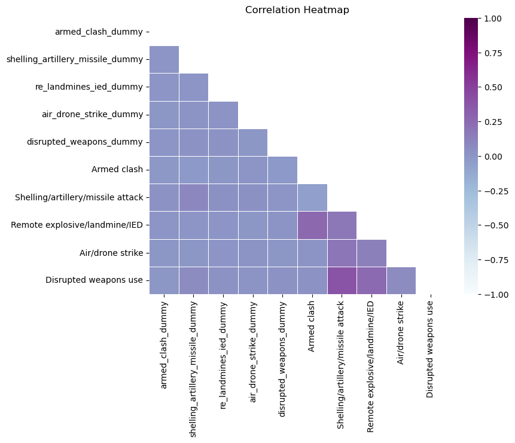

By analyzing the correlations between the events counts from the world-news subreddit and ACLED, it can be concluded that they are not quite similar. It suggests that the world news subreddit may not account for all the regional-level news events that ACLED captures, thereby having lower counts for the same sub-event types.